## Ethereum Cryptocurrency Time Series Forecasting

Ethereum is a decentralized, open-source blockchain with smart contract functionality. Ether (ETH or Ξ) is the native cryptocurrency of the platform. Ether is second only to Bitcoin in market capitalization.[1](https://en.wikipedia.org/wiki/Ethereum) As with any currency/commodity on the market, Ethereum trading and financial instruments soon followed public adoption of Ethereum and continue to grow.

This Kernel is divided into three parts:-

- Data Proccesing.
- Time Series Analysis:
  - Time Series forecasting with ARIMA.
  - Time Series forecasting with Facebook Prophet.
- Model comparison.

## Data

Historical Ethereum daily data from 2016 to 2021 from Kaggle available [here.](https://www.kaggle.com/kaushiksuresh147/ethereum-cryptocurrency-historical-dataset)

## Setup

```r
# Libraries
library(magrittr) # needs to be run every time you start R and want to use %>%
library(tibble)
library(tidyverse)
library(dplyr)


# Ethereum data
data <- read.csv("Ethereum Historical Data.csv",  header = T)

head(data)
```

```
##         Date  Open  High   Low Close Volume
## 1 2016-03-10 11.20 11.85 11.07 11.75      4
## 2 2016-03-11 11.75 11.95 11.75 11.95    179
## 3 2016-03-12 11.95 13.45 11.95 12.92    833
## 4 2016-03-13 12.92 15.07 12.92 15.07   1295
## 5 2016-03-14 15.07 15.07 11.40 12.50  92183
## 6 2016-03-15 12.63 13.42 11.98 13.06  39725
```

We are interested in predicting the Closing variable at the end of each day which is represented by the column Close.

- Close: Closing price of the time interval (in USD).

```r
# Libraries
library(lubridate)

y = ts(data$Close, start=c(2016, yday("2016-03-10")), frequency=365)

# Splitting the data to train and test sets
train <- subset(y, end=length(y)-100)
test <- subset(y, start=length(y)-99)
```

For the evaluation, we divided the time series into a train and test datasets where the training series consists of the data until from 2016-03-10 to 2021-11-23.

## Time Series Analysis

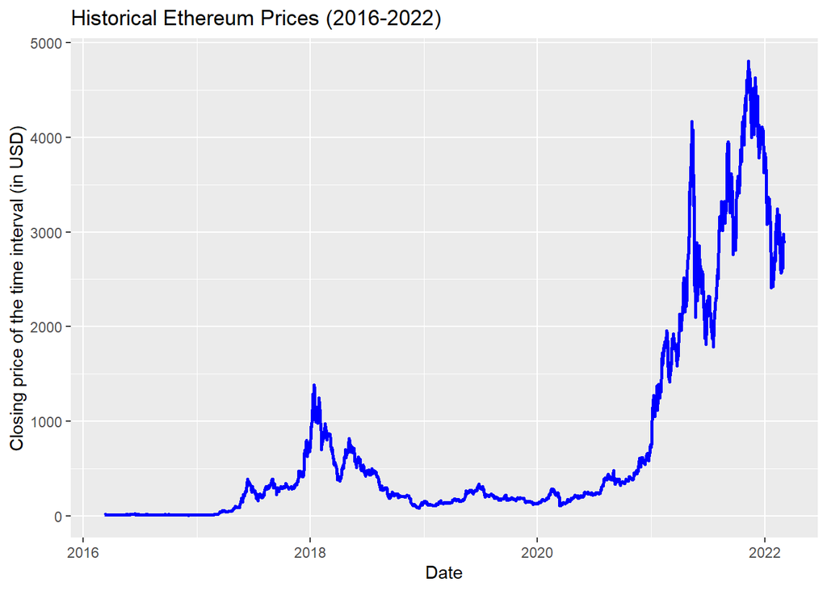

Now, let’s get started with our main models:

## Time Series forecasting with ARIMA

The main advantage of auto_arima is that it employs a grid search that determines the optimal parameters. The auto.arima return the model with the smallest AIC value.

```r
# Libraries
library(FitARMA)
library(forecast)

# Setup and train model
arimafit <- auto.arima(train)

# Forecasting with ARIMA
arima <- forecast(arimafit,h=100)
```

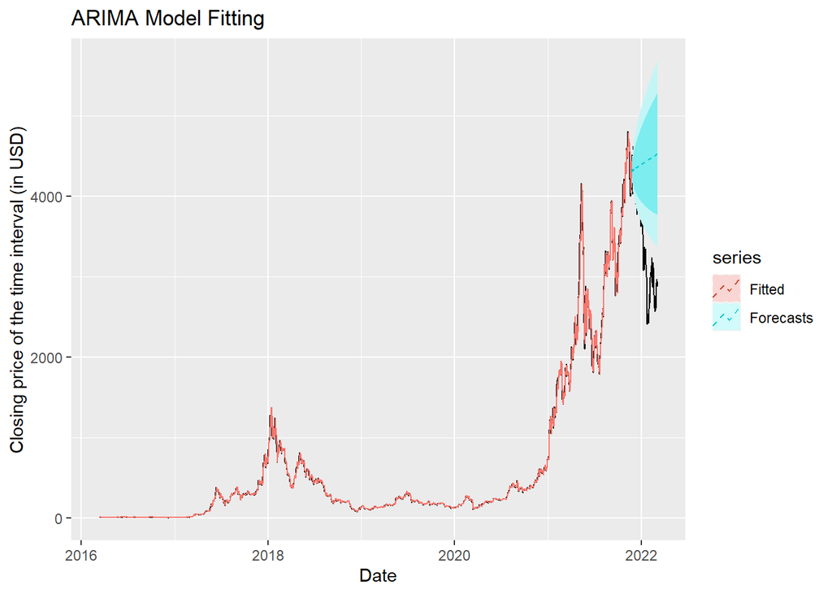

```r
# Libraries
library(ggplot2)

# Plot ARIMA forecast
autoplot(y) +
  autolayer(arimafit$fitted, series = "Fitted")+
  autolayer(arima, series = "Forecasts", linetype = "dashed")+
  ggtitle("ARIMA Model Fitting") + xlab("Date") +
  ylab("Closing price of the time interval (in USD)")
```

## Time Series forecasting with Prophet

We use the publicly available R implementation of Prophet.

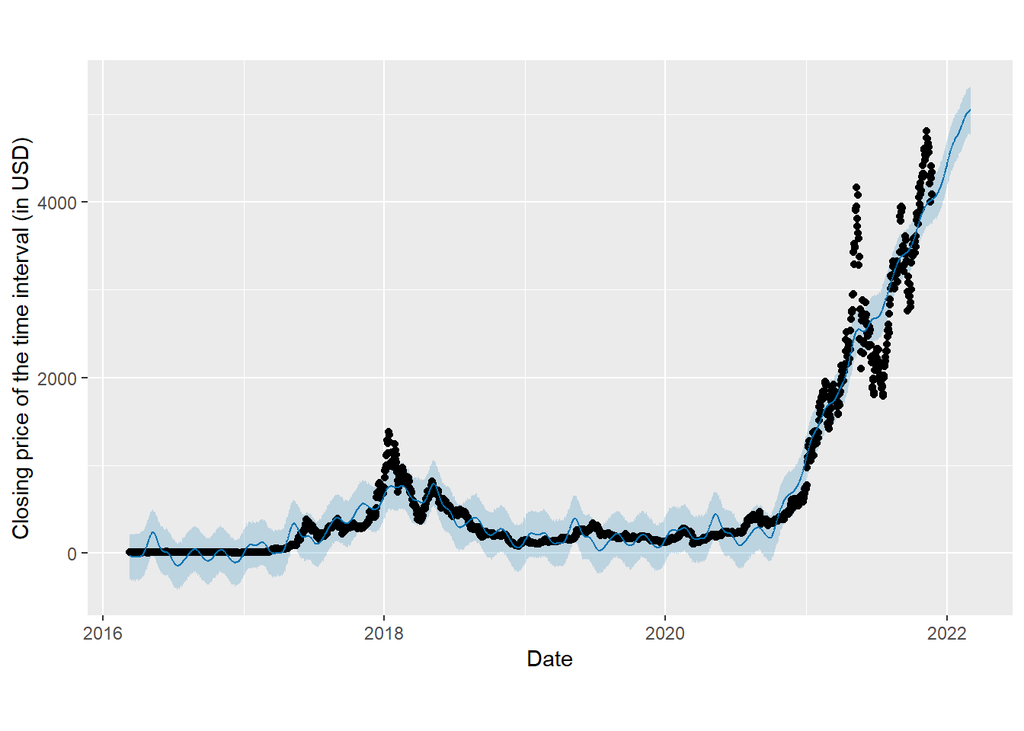

```r
# Libraries
library(prophet)
library(TSstudio)

# set the ts object
df = ts_to_prophet(ts.obj = train, start = as.Date("2016-03-10"))

test_prophet = ts_to_prophet(ts.obj = test, start = as.Date("2021-11-23"))

# Forecasting with Facebook's prophet package
m <- prophet(df)
future <- make_future_dataframe(m, periods = 100)
forecast <- predict(m, future)

# Plot prophet forecast
plot(m, forecast,xlab = "Date",ylab = "Closing price of the time interval (in USD)", main = "Prophet Model Fitting")
```

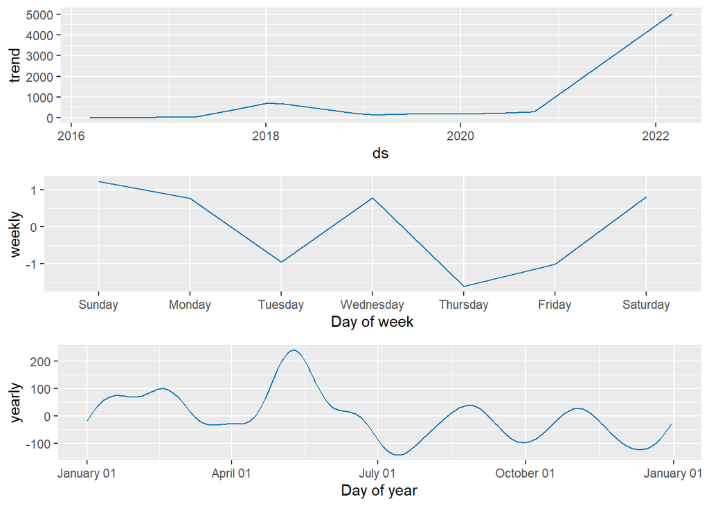

```r
prophet_plot_components(m, forecast)
```

```r
tail(future)
```

```
##              ds
## 2180 2022-02-26
## 2181 2022-02-27
## 2182 2022-02-28
## 2183 2022-03-01
## 2184 2022-03-02
## 2185 2022-03-03
```

```r
# Interactive plot
dyplot.prophet(m, forecast)
```

[interactive chart not shown]

## Model comparison

Which model yields the most accurate predictions for the test dataset, we will need to see how these two models fare against each other.

```r
library("Metrics")

# Comparing the models performance

# Actual values length
length(test)
```

```
## [1] 100
```

```r
# Save the ARIMA predictions as a vector
arima_forecasts = arima$mean

# Check the length
length(arima_forecasts)
```

```
## [1] 100
```

```r
mae(test, arima_forecasts)
```

```
## [1] 1052.57
```

```r
rmse(test, arima_forecasts)
```

```
## [1] 1240.15
```

```r
mape(test, arima_forecasts)
```

```
## [1] 0.3583097
```

```r
# Prophet

# Save the prophet predictions as a vector
predicted_prophet = forecast[forecast$ds >= "2021-11-23" & forecast$ds <= "2022-03-03",]
prophet_forecasts = predicted_prophet$trend

# Check the length
length(prophet_forecasts)
```

```
## [1] 100
```

```r
mae(test, prophet_forecasts)
```

```
## [1] 1207.097
```

```r
rmse(test, prophet_forecasts)
```

```
## [1] 1447.287
```

```r
mape(test, prophet_forecasts)
```

```
## [1] 0.4126063
```

Here lets visualize and compare the predictive results of ARIMA, and Prophet in a single plot,

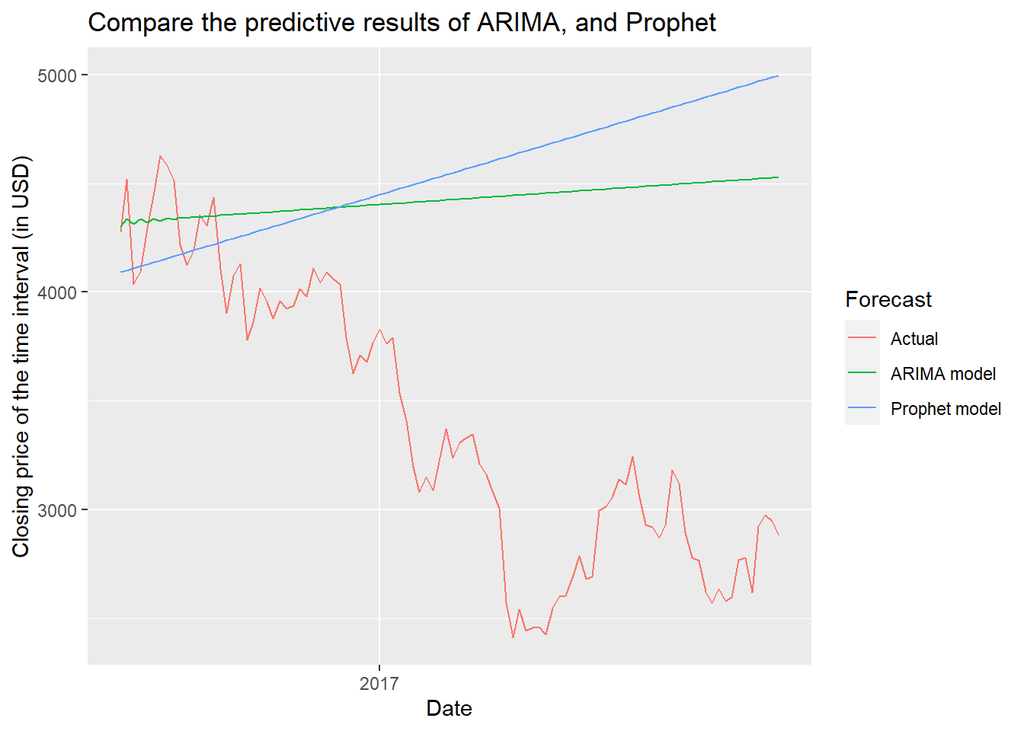

#### Conclusion

The Ethereum prices are very volatile and very random, and is often influenced by external factors (or news) such as Cryptocurrency regulations, Investments or simple rumors on social media. We need additional data from other open data sources such as news or social media to make these models perform better and more accurately.